# model_building

2025-02-21

### 1. Check whether genetic PCs are associated with the genetic category exposure

| covar | mean_prefer_carb | mean_prefer_fat | t_stat | p |
| --- | --- | --- | --- | --- |
| PC1 | 0.13 | 0.07 | 0.97 | 0.36 |
| PC2 | -0.26 | -0.23 | -1.16 | 0.27 |
| PC3 | 0.00 | 0.00 | -0.65 | 0.52 |
| PC4 | -0.08 | -0.07 | -1.70 | 0.12 |
| PC5 | 0.01 | 0.00 | 1.40 | 0.19 |

None of the genetic PCs are significantly associated with the genetic category exposure (via t-tests)

### 2. Check whether genetic PCs are associated with fasting or iAUC metabolite outcomes

#### Univariate associations

##### Model: metabolite ~ PC (estimates shown are for the PC association)

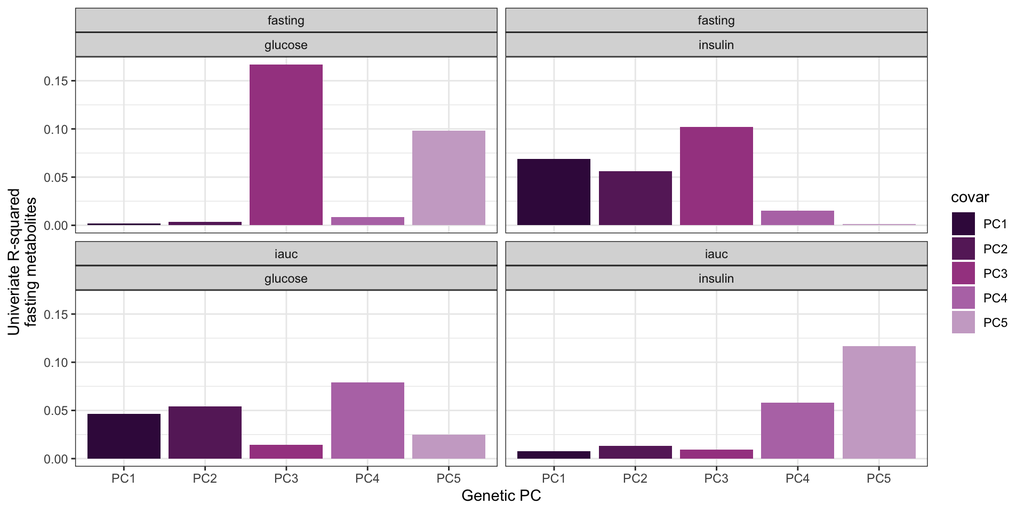

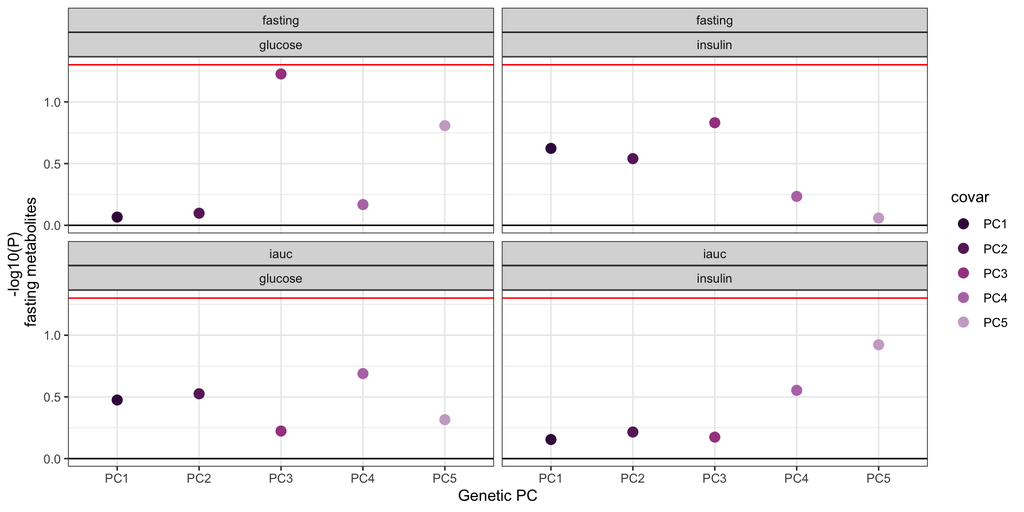

- R2: PC3 seems to have a high r2 for fasting glucose and insulin
- Pvals (shown on -log10(P) scale): None of the genetic PCs are significantly associated with any of the fasting or iAUC metabolites (all >0.05)

#### Multivariate associations, with genetic category

##### Mmodel: metabolite ~ PC + genetic category

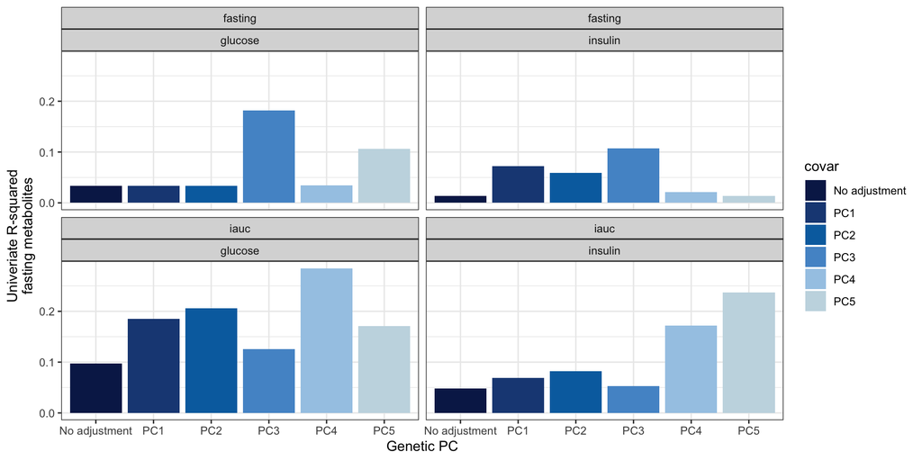

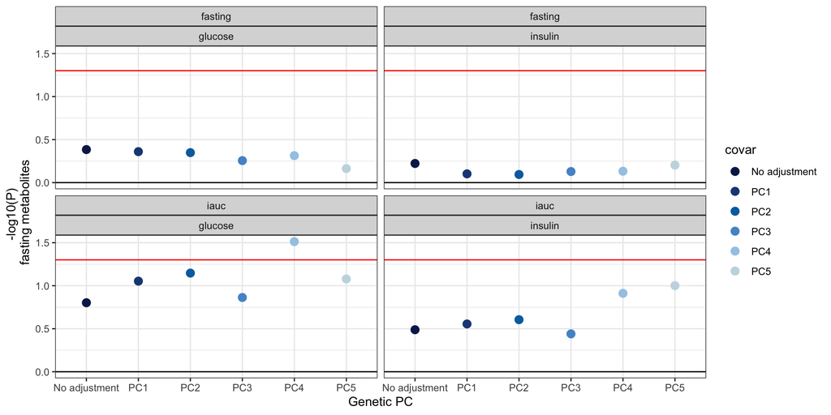

- R2 with PC3 expalins mroe variability in fasting glucose & insulin than model without genetic PCs. For iAUC metabolites, seems to be some benefit for including even more PCs (PC4 for glucose; PC5 for insulin)
- Adding adjustment for gentic PCs (PC4) improves strength of association between genetic category and iAUC metabolites; specifically PC4 (i.e., genetic category + PC4 was significant, while genetic category alone was not).
- Note improvements for insulin as well for PC4

#### Multivariate associations with with genetic category and sequential PC adjustment

model: metabolite ~ PC + genetic category (estimates shown are for the adjusted genetic category association)

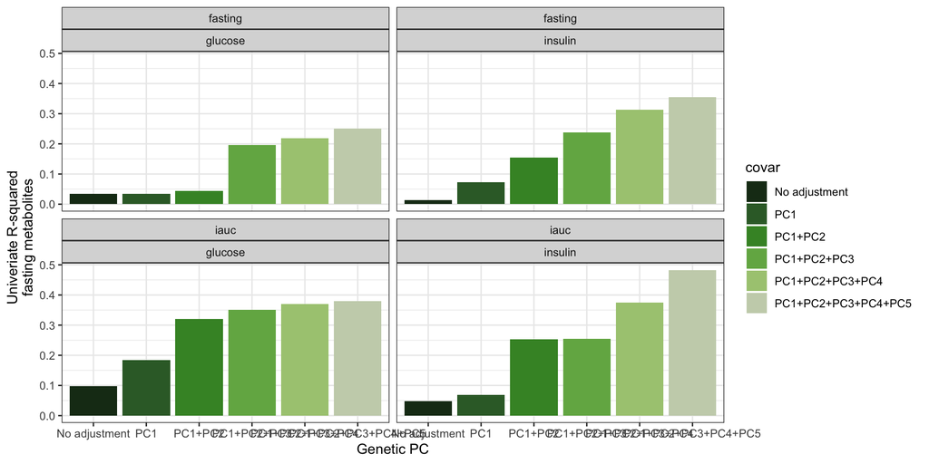

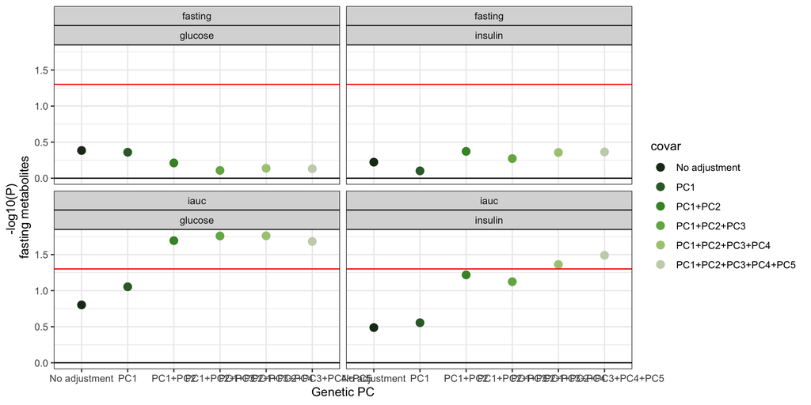